# Different Taxes and their development in Germany

#### Introduction

The german federal statistics office (DEStatis) offers several different datasets about the federal tax income of germany. Using the monthly and quarterly tax income data (uncorrected and before allocation), we want to look at the following research questions:

- How has the overall tax income developed over the past 20 years?
- Can we see seasonal variations in the data, specifically in the consumer goods taxes?
- What role did the air traffic tax play in the overall tax income since it's introduction in 2011?
- How do the wage tax and the three assets taxes (wealth, solidarity, inheritance) compare to each other? Has this ratio changed over the past 20 years?

#### Preprocessing The Data

Firstly, we need to process the source data and load it into the notebook. The `process_source_data` function cleans the raw data that can be downloaded from the DEStatis website and transforms it into numerical values, with proper NaN-types where values are missing.

Sometimes, we will also want to look at the tax income for whole years. Therefore, we create another yearly dataset by summing up 4 consecutive values of the quarterly dataset for each tax type.

```python
import pandas as pd
import numpy as np
import matplotlib.pyplot as plt
from helper_functions import process_source_data

BASE_DIR = '/home/nils/Documents/Repositories/semester-10/rse/rse_24_individual_project/'
```

```python
process_source_data('data/71211-0005_$F.csv', 'results/monthly_tax_data.csv', False)
process_source_data('data/71211-0003_$F.csv', 'results/quarterly_tax_data.csv', True)

df_m = pd.read_csv(BASE_DIR + 'results/monthly_tax_data.csv', index_col=0).astype('Int64')
df_q = pd.read_csv(BASE_DIR + 'results/quarterly_tax_data.csv', index_col=0).astype('Int64')

yearly_data = []
for i in range(0, len(df_q.columns), 4):
    yearly_data.append(df_q.iloc[:, i:i+4].sum(axis=1).values)
df_y = pd.DataFrame(np.transpose(yearly_data), index=df_q.index, columns=range(1999, 2024))
```

We can confirm the number of rows and columns of all 3 datasets and also look at the number of NaN values (Use pandas' .info() method to find out about the exact column names):

```python
print(f'Tax types:\n{df_m.index.values}\n')
print(f'Monthly data: {df_m.shape[0]} rows, {df_m.shape[1]} columns, {df_m.isna().sum().sum()/(df_m.shape[0]*df_m.shape[1]):0.2f}% NaN values')
print(f'Quarterly data: {df_q.shape[0]} rows, {df_q.shape[1]} columns, {df_q.isna().sum().sum()/(df_q.shape[0]*df_q.shape[1]):0.2f}% NaN values')
print(f'Yearly data: {df_y.shape[0]} rows, {df_y.shape[1]} columns, {df_y.isna().sum().sum()/(df_y.shape[0]*df_y.shape[1]):0.2f}% NaN values')
```

```
Tax types:
['Steuereinnahmen insgesamt' 'Lohnsteuer' 'Umsatzsteuer' 'Tabaksteuer'
 'Kaffeesteuer' 'Alkoholsteuer' 'Alcopopsteuer' 'Schaumweinsteuer'
 'Energiesteuer' 'Stromsteuer' 'Luftverkehrsteuer' 'Solidaritätszuschlag'
 'Vermögensteuer' 'Erbschaftsteuer' 'Biersteuer' 'Getränkesteuer'
 'Schankerlaubnissteuer']

Monthly data: 17 rows, 312 columns, 0.24% NaN values
Quarterly data: 17 rows, 100 columns, 0.15% NaN values
Yearly data: 17 rows, 25 columns, 0.00% NaN values
```

#### Question 1: How has the overall tax income developed over the past 20 years?

Both the blue and the black line clearly show us that the tax income has increased compared to 20 years ago. We do, however see

1. a period of stagnation (1999-2005)
2. a sharp increase (2006-2008)
3. followed by a short decline (2009-2010), possibly due to the financial crisis in 2008
4. a steady increase (2011-2023)
5. that is only disrupted heavily by the Covid crisis in 2020

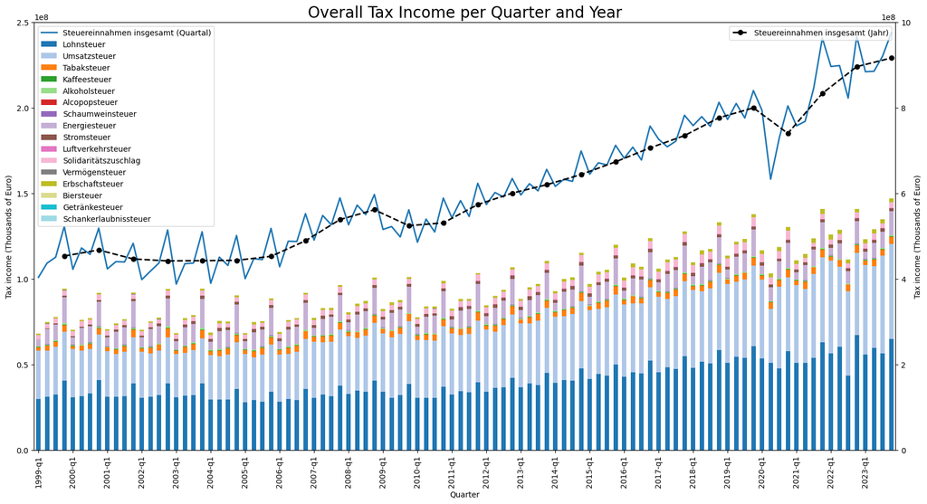

```python
ax = plt.figure(figsize=(20, 10)).gca()
ax2 = ax.twinx()

# use the pandas bar plot function for convenience and assign it to our existing axis
df_q[1:].T.plot(ax=ax, kind='bar', stacked=True, colormap='tab20')
# plot the total tax income per quarter (using left y-axis)
ax.plot(df_q.iloc[0, :], linewidth=2, label='Steuereinnahmen insgesamt (Quartal)')
# and per year on the 4th quarter (using right y-axis)
ax2.plot(range(3, len(df_q.columns), 4), df_y.iloc[0, :], 'o--', color='black', linewidth=2, label='Steuereinnahmen insgesamt (Jahr)')

ax.legend()
ax2.legend()
# set the x-axis ticks to the quarter numbers
ax.set_xticks(range(0, len(df_q.columns), 4))
# set y-axis limits
ax.set_ylim(0, 2.5e8)
ax2.set_ylim(0, 10e8)
# format the right y-axis to use the same scientific notation unit as the left y-axis
ax2.ticklabel_format(axis='y', style='sci', scilimits=(8, 8))

# add title and axis labels
ax.set_title('Overall Tax Income per Quarter and Year', fontsize=20)
ax.set_xlabel('Quarter')
ax.set_ylabel('Tax income (Thousands of Euro)')
ax2.set_ylabel('Tax income (Thousands of Euro)')
plt.savefig(BASE_DIR + 'results/question_1.png')
plt.show()
```

#### Question 2: Can we see seasonal variations in the data, specifically in the consumer goods taxes?

To answer the second question, we will look more closely at 6 different taxes and use the monthly dataset. We will also use a different visualization: By showing each year as an individual line plot from January to December, we can see how the consumer goods tax income changes both within a year and over multiple years. The figures each show the years 1999-2019 in a light to darker blue, and the (post-)covid years in red, yellow, and green for distinction. The mean value over all years is shown in a black dotted line.

Looking at the data, we have to keep in mind that tax income values generally increase through the year with a huge spike in December, as we saw earlier. Still, the six figures tell us multiple interesting insights:

- The tabacco tax income (upper left) shows a clear dip in January and Februar, probably relating to many people's new year's resolutions. We can also see that many people presumably drop their resolutions as early as March, when tax income recoveres to a steady level for the rest of the year.
- Coffe tax income (upper right) shows a distinctive spike in April, which could be related to Easter Holidays, which is a typically celebrated with a brunch and coffee by many families.
- Sparkling wine tax income (lower left) shows clear spikes in March (formerly) and February (more recently). These spikes could be related to carnival celebrations (though the shift from March to February remains unexplained). The December spike in the data is also stronger than for the other tax types, likely due to preparations for new year's celebrations. The sparkling wine tax income pattern also dominates the total alcohol tax income pattern (middle left).
- The beer tax income (lower right) shows a clear seasonal curve, with high values in summer months and lower values during spring and winter (except for January, interestingly). Here we can also see the strongest impact of the Covid pandemic during the early summer months of 2020. Additionally, we can see a general downwards trend in the beer tax income over the years, with the lighter blue lines consistently lining up above the darker blue lines.
- The alcopop tax income (middle right) is hard to interpret, with small values and little variation and two outliners visible.

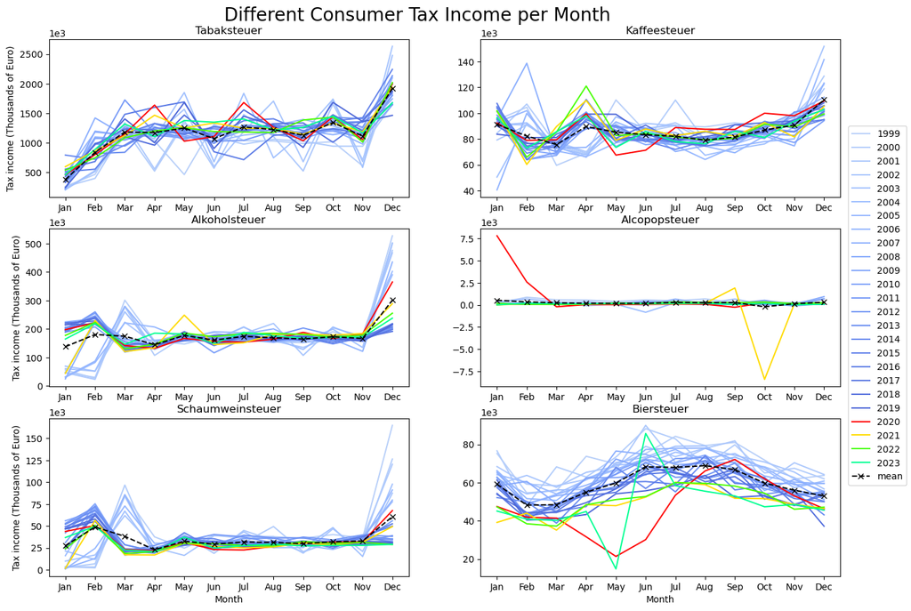

```python
fig, ax = plt.subplots(figsize=(15, 10), nrows=3, ncols=2)
# indices for the tax types we want to analyze
consumer_tax_indeces = [3, 4, 5, 6, 7, 14]

for i, tax_index in enumerate(consumer_tax_indeces):
    # create a new dataframe with years as row and months as columns
    # only for the selected tax type for easier visualization
    data = pd.DataFrame(index=range(1999, 2024), columns=range(1, 13))
    for year in range(0, 25):
        data.iloc[year, :] = df_m.iloc[tax_index, year*12:year*12+12]

    # two different color maps for pre and post covid data
    colors = iter([plt.cm.coolwarm(a) for a in reversed(range(0, 100, 100//21))])
    covid_colors = iter([plt.cm.hsv(a) for a in range(0, 150, 150//4)])

    # index for the subplot location
    plot_loc = (i // 2, i % 2)

    for year in range(0, 25):
        # skip the first 6 years of the 'Alcopops' tax type
        # as it was only introduced in 2005
        if tax_index == 6 and year < 7:
            continue

        # use different colors for pre and post covid data
        if year > 20:
            ax[plot_loc].plot(range(0, 12), data.iloc[year, :], label=str(1999 + year), color=next(covid_colors), linewidth=1.5)
        else:
            ax[plot_loc].plot(range(0, 12), data.iloc[year, :], label=str(1999 + year), color=next(colors))

    # plot the mean of all years for each month
    monthly_mean = [data.iloc[:, month].mean() for month in range(0, 12)]
    ax[plot_loc].plot(range(0, 12), monthly_mean, 'x--', label='mean', color='black')

    # set the same scientific notation unit and month names for all subplots
    ax[plot_loc].ticklabel_format(axis='y', style='sci', scilimits=(3, 3))
    ax[plot_loc].set_xticks(range(0, 12, 1), labels=['Jan', 'Feb', 'Mar', 'Apr', 'May', 'Jun', 'Jul', 'Aug', 'Sep', 'Oct', 'Nov', 'Dec'])

    ax[plot_loc].set_title(df_m.index[tax_index])
    if i == 0 or i == 2 or i == 4:
        ax[plot_loc].set_ylabel('Tax income (Thousands of Euro)')
    if i == 5 or i == 4:
        ax[plot_loc].set_xlabel('Month')

# add single legend for all subplots
handles, labels = ax[0, 0].get_legend_handles_labels()
plt.figlegend(handles, labels, loc='right')

fig.suptitle('Different Consumer Tax Income per Month', fontsize=20)
fig.subplots_adjust(right=0.93, top=0.93)
plt.savefig(BASE_DIR + 'results/question_2.png')
plt.show()
```

#### Question 3: What role did the air traffic tax play in the overall tax income since it's introduction in 2011?

For the third question, we only look at the yearly tax income. To achieve this, we can simply sum up 4 subsequent entries from the quarterly dataset and store them in a new dataframe. Plotting the absolute values (left), we can see that the air traffic tax income developed similar to the total tax income. The break in the income due to Covid, is, however much sharper for the air traffic tax income compared to the total tax income. This makes sense, since in 2020 almost no air traffic was possible for significant parts of the year, especially in the tourism sector. The percentual values (right) show us that air traffic actually makes up only a very small portion of total tax income: Except for the dip due to Covid, air traffic is responsible for a steady 0.16 percent of the total tax income.

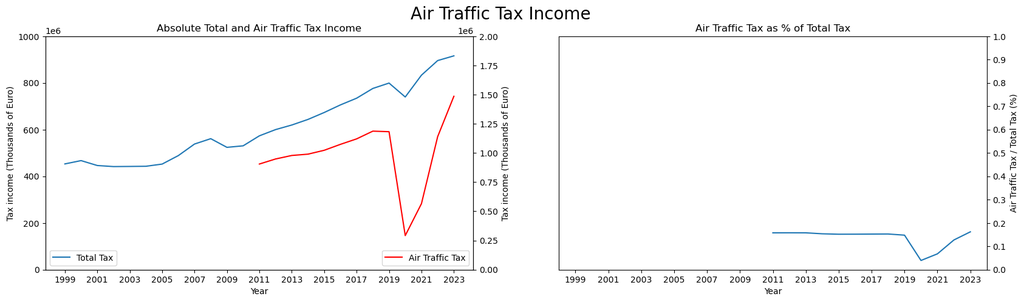

```python
fig, ax = plt.subplots(figsize=(20, 5), nrows=1, ncols=2)

# plot total tax income
ax[0].plot(df_y.iloc[0, :], label='Total Tax')
# and air traffic tax income in the same plot
ax2 = ax[0].twinx()
ax2.plot(df_y.iloc[10, 12:], 'r', label='Air Traffic Tax')
# plot air traffic tax as percentage of total tax income in second plot
ax[1].plot(df_y.iloc[10, 12:] / df_y.iloc[0, :] * 100)

# figure adjustments
ax[0].legend(loc='lower left')
ax[0].ticklabel_format(axis='y', style='sci', scilimits=(6, 6))
ax[0].set_ylim(0, 1000e6)
ax[0].set_xticks(range(1999, 2024, 2))
ax[0].set_ylabel('Tax income (Thousands of Euro)')
ax[0].set_xlabel('Year')
ax[0].set_title('Absolute Total and Air Traffic Tax Income')

ax2.legend(loc='lower right')
ax2.set_ylim(0, 2e6)
ax2.set_ylabel('Tax income (Thousands of Euro)')

ax[1].set_ylim(0, 1)
ax[1].yaxis.set_ticks(np.arange(0, 1.1, 0.1))
ax[1].yaxis.set_label_position('right')
ax[1].yaxis.tick_right()
ax[1].set_xlim(1998, 2024)
ax[1].set_xticks(range(1999, 2024, 2))
ax[1].set_ylabel('Air Traffic Tax / Total Tax (%)')
ax[1].set_xlabel('Year')
ax[1].set_title('Air Traffic Tax as % of Total Tax')

fig.suptitle('Air Traffic Tax Income', fontsize=20)
plt.savefig(BASE_DIR + 'results/question_3.png')
plt.show()
```

#### Question 4: How do the wage tax and the three weatlh taxes (asset, solidarity, inheritance) compare to each other? Has this ratio changed over the past 20 years?

As before, we will look at the yearly data to answer this question. Firstly we can plot all 4 tax incomes at once (top): The bars show the composition of solidarity, asset, and inheritance tax, while the red line shows the wage tax, which has a scale multiplied by 10. The bars and the line follow a similar pattern overall, with the notable exceptions of 1) the asset tax almost disappearing after 2005 and 2) a decoupling of the two categories after 2020.

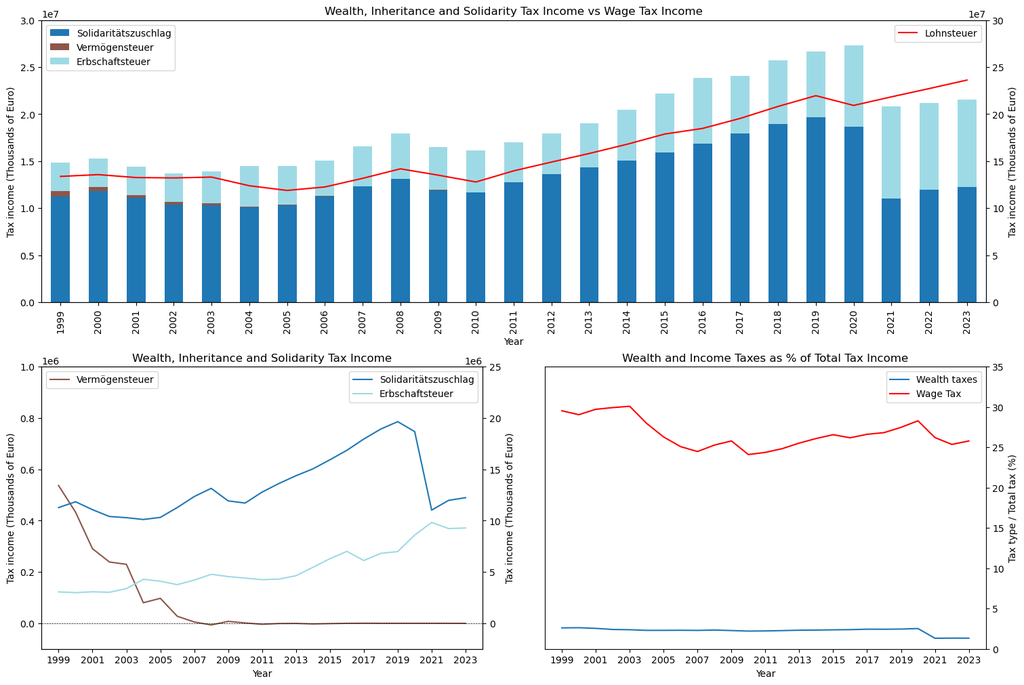

```python
fig, ax = plt.subplot_mosaic("AA;BC", constrained_layout=True)

# Figure 1
# use pandas plot function for convenience
df_y.iloc[[11, 12, 13], :].T.plot(ax=ax['A'], kind='bar', stacked=True, colormap='tab20', figsize=(15, 10))
ax['A'].set_ylim(0, 3e7)
ax['A'].set_xlabel('Year')
ax['A'].set_ylabel('Tax income (Thousands of Euro)')
ax['A'].set_title('Wealth, Inheritance and Solidarity Tax Income vs Wage Tax Income')
ax['A'].legend()

# right axis for wage tax income
ax2 = ax['A'].twinx()
ax2.plot(df_y.iloc[1, :].to_list(), 'r', label='Lohnsteuer')
ax2.set_ylim(0, 30e7)
ax2.ticklabel_format(axis='y', style='sci', scilimits=(7, 7))
ax2.set_ylabel('Tax income (Thousands of Euro)')
ax2.legend()

# Figure 2
# only plot the asset tax on left axis
ax['B'].plot(df_y.iloc[12, :], label='Vermögensteuer', color=plt.cm.tab20(10))
ax['B'].axhline(0, linestyle='--', color='black', linewidth=0.5)
ax['B'].set_ylim(-1e5, 1e6)
ax['B'].ticklabel_format(axis='y', style='sci', scilimits=(6, 6))
ax['B'].set_xlim(1998, 2024)
ax['B'].set_xticks(range(1999, 2024, 2))
ax['B'].set_xlabel('Year')
ax['B'].set_ylabel('Tax income (Thousands of Euro)')
ax['B'].set_title('Wealth, Inheritance and Solidarity Tax Income')
ax['B'].legend(loc='upper left')

# right axis for inheritance and solidarity tax income
ax2 = ax['B'].twinx()
ax2.plot(df_y.iloc[11, :], label='Solidaritätszuschlag', color=plt.cm.tab20(0))
ax2.plot(df_y.iloc[13, :], label='Erbschaftsteuer', color=plt.cm.tab20(20))
ax2.set_ylim(-25e5, 25e6)
ax2.ticklabel_format(axis='y', style='sci', scilimits=(6, 6))
ax2.set_ylabel('Tax income (Thousands of Euro)')
ax2.legend(loc = 'upper right')

# Figure 3
# plot wealth and wage tax as percentage of total tax income
ax['C'].plot(df_y.iloc[11:13, :].sum(axis=0) / df_y.iloc[0, :] * 100, label='Wealth taxes')
ax['C'].plot(df_y.iloc[1, :] / df_y.iloc[0, :] * 100, label='Wage Tax', color='r')
ax['C'].set_ylim(0, 35)
ax['C'].yaxis.set_label_position('right')
ax['C'].yaxis.tick_right()
ax['C'].set_xlim(1998, 2024)
ax['C'].set_xticks(range(1999, 2024, 2))
ax['C'].set_xlabel('Year')
ax['C'].set_ylabel('Tax type / Total tax (%)')
ax['C'].set_title('Wealth and Income Taxes as % of Total Tax Income')
ax['C'].legend()

plt.savefig(BASE_DIR + 'results/question_4.png')
plt.show()
```